# Reproducible Research: Peer Assessment 1

## Loading and preprocessing the data

```r
#unzip data to activity.csv file

unzip("activity.zip",overwrite = TRUE)

#read data and specify default types for columns
   #steps = numeric
   #date = Date
   #interval = numeric

data<-read.csv("activity.csv",header = T,na.strings = c("NA"),colClasses = c("numeric","Date","numeric"))
```

The structure for read data is:

```r
str(data)
```

```
## 'data.frame':    17568 obs. of  3 variables:
##  $ steps   : num  NA NA NA NA NA NA NA NA NA NA ...
##  $ date    : Date, format: "2012-10-01" "2012-10-01" ...
##  $ interval: num  0 5 10 15 20 25 30 35 40 45 ...
```

```r
head(data)
```

```
##   steps       date interval
## 1    NA 2012-10-01        0
## 2    NA 2012-10-01        5
## 3    NA 2012-10-01       10
## 4    NA 2012-10-01       15
## 5    NA 2012-10-01       20
## 6    NA 2012-10-01       25
```

## What is mean total number of steps taken per day?

```r
#load required libraries
library(dplyr)
```

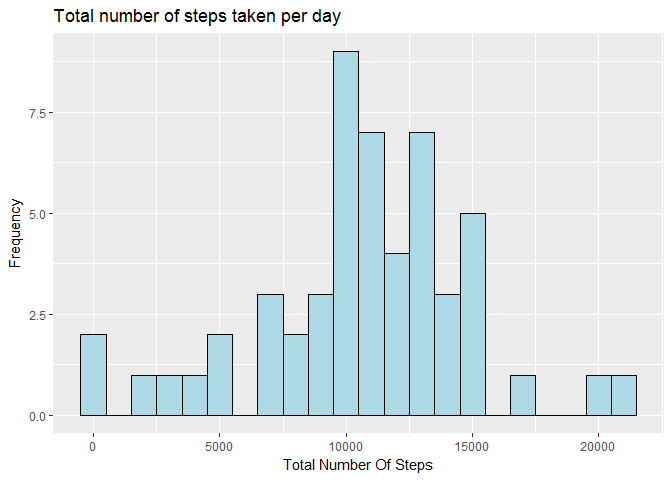

```r
library(ggplot2)

#get data sumarized per dat
sumarized<-data %>% filter(!is.na(steps)) %>% group_by(date) %>% summarize(totalSteps=sum(steps))


#plot mean total number of steps per day
ggplot(sumarized,aes(x=totalSteps))+geom_histogram(binwidth=1000,color="black",fill="lightblue")+labs(title="Total number of steps taken per day",x="Total Number Of Steps",y="Frequency")
```

The values for mean and median total number of streps taken per day are:

*Mean:*

```r
mean(sumarized$totalSteps)
```

```
## [1] 10766.19
```

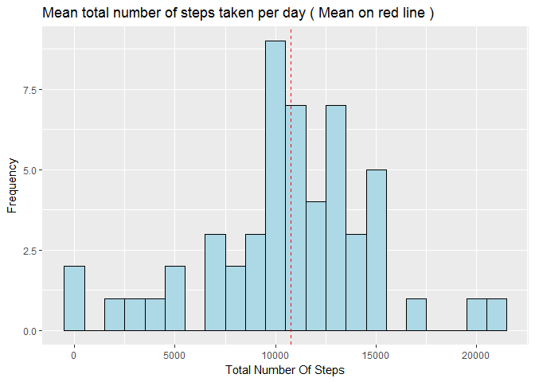

```r
#plot mean total number of steps per day

histplot<-ggplot(sumarized,aes(x=totalSteps))+geom_histogram(binwidth=1000,color="black",fill="lightblue")
histplot<-histplot + labs(title="Mean total number of steps taken per day ( Mean on red line )",x="Total Number Of Steps",y="Frequency")
histplot+geom_vline(aes(xintercept=mean(totalSteps)),color="red",linetype="dashed",show.legend = T)
```

*Median:*

```r
median(sumarized$totalSteps)
```

```
## [1] 10765
```

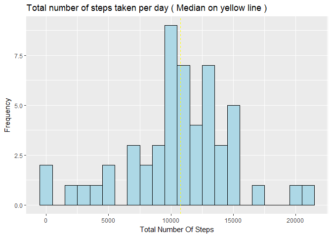

```r
#plot mean total number of steps per day

histplot<-ggplot(sumarized,aes(x=totalSteps))+geom_histogram(binwidth=1000,color="black",fill="lightblue")
histplot<-histplot + labs(title="Total number of steps taken per day ( Median on yellow line )",x="Total Number Of Steps",y="Frequency")
histplot+geom_vline(aes(xintercept=median(totalSteps)),color="yellow",linetype="dashed",show.legend = T)
```

## What is the average daily activity pattern?

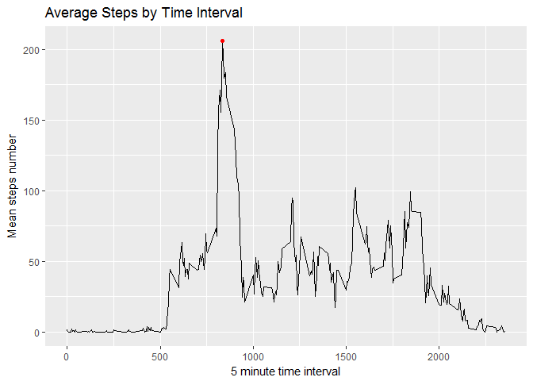

```r
#load required libraries
library(dplyr)
library(ggplot2)

#get data sumarized per dat
sumarized<-data %>% filter(!is.na(steps)) %>% group_by(interval) %>% summarize(meanSteps=mean(steps))

#get max value coordenates
interval = which.max(sumarized$meanSteps)
pointdata = sumarized[interval,]

#plot mean total number of steps per day

histplot<-ggplot(sumarized,aes(x=interval,y=meanSteps))+geom_line(color="black")
histplot<-histplot + labs(title="Average Steps by Time Interval",x="5 minute time interval",y="Mean steps number")
histplot<-histplot + geom_point(data=pointdata,aes(x=interval,y=meanSteps),color="red")
histplot#autoprint
```

```r
output <- paste("Max Value is:",pointdata[1,2]," on interval ",pointdata[1,1])
print(output)
```

```
## [1] "Max Value is: 206.169811320755  on interval  835"
```

## Imputing missing values

Note that there are a number of days/intervals where there are missing values (coded as NA). The presence of missing days may introduce bias into some calculations or summaries of the data.

1 Calculate and report the total number of missing values in the dataset (i.e. the total number of rows with NAs)

```r
sum(is.na(data$steps))
```

```
## [1] 2304
```

2 Devise a strategy for filling in all of the missing values in the dataset. The strategy does not need to be sophisticated. For example, you could use the mean/median for that day, or the mean for that 5-minute interval, etc.

Create a new dataset that is equal to the original dataset but with the missing data filled in.

```r
data[is.na(data)] <- mean(data$steps,na.rm = T)
```

3 Make a histogram of the total number of steps taken each day and Calculate and report the mean and median total number of steps taken per day. Do these values differ from the estimates from the first part of the assignment? What is the impact of imputing missing data on the estimates of the total daily number of steps?

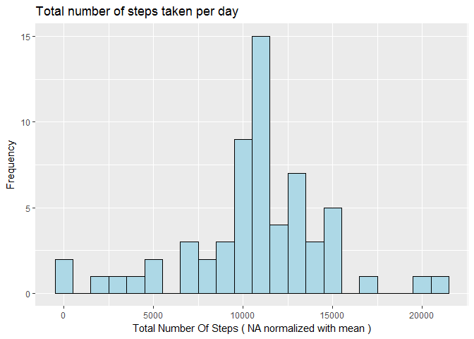

```r
#load required libraries
library(dplyr)
library(ggplot2)

#get data sumarized per dat
sumarized<-data  %>% group_by(date) %>% summarize(totalSteps=sum(steps))


#plot mean total number of steps per day
ggplot(sumarized,aes(x=totalSteps))+geom_histogram(binwidth=1000,color="black",fill="lightblue")+labs(title="Total number of steps taken per day",x="Total Number Of Steps ( NA normalized with mean )",y="Frequency")
```

*Mean:*

```r
mean(sumarized$totalSteps)
```

```
## [1] 10766.19
```

[figure not shown]

```r
#plot mean total number of steps per day

histplot<-ggplot(sumarized,aes(x=totalSteps))+geom_histogram(binwidth=1000,color="black",fill="lightblue")
histplot<-histplot + labs(title="Missing Values Removed",x="Total Number Of Steps",y="Frequency")
histplot+geom_vline(aes(xintercept=mean(totalSteps)),color="red",linetype="dashed",show.legend = T)
```

*Median:*

```r
median(sumarized$totalSteps)
```

```
## [1] 10766.19
```

[figure not shown]

```r
#plot mean total number of steps per day

histplot<-ggplot(sumarized,aes(x=totalSteps))+geom_histogram(binwidth=1000,color="black",fill="lightblue")
histplot<-histplot + labs(title="Missing Values Removed",x="Total Number Of Steps",y="Frequency")
histplot+geom_vline(aes(xintercept=median(totalSteps)),color="yellow",linetype="dashed",show.legend = T)
```

## Are there differences in activity patterns between weekdays and weekends?

For this part the weekdays() function may be of some help here. Use the dataset with the filled-in missing values for this part.

1 Create a new factor variable in the dataset with two levels – “weekday” and “weekend” indicating whether a given date is a weekday or weekend day.

```r
weekpart = function(x){
  if(x=="sabado" || x=="domingo"){
    return('Weekend')
  }

  return('Weekday')
}

data$dayname <- weekdays(data$date)
data$daytpe<- as.factor(apply(as.matrix(data$dayname), 1, weekpart))
```

```r
sumarizedwd = data %>% filter(daytpe=="Weekday") %>% group_by(interval) %>%summarize(meanSteps=mean(steps))
sumarizedwe = data %>% filter(daytpe=="Weekend") %>% group_by(interval) %>%summarize(meanSteps=mean(steps))

library(gridExtra)
```

[figure not shown]

```r
wdplot<-ggplot(sumarizedwd,aes(x=interval,y=meanSteps))+geom_line(color="black")
wdplot<-wdplot + labs(title="Weekday",x="Interval",y="Number of steps")

weplot<-ggplot(sumarizedwe,aes(x=interval,y=meanSteps))+geom_line(color="black")
weplot<-weplot + labs(title="Weekday",x="Interval",y="Number of steps")

grid.arrange(wdplot, weplot,nrow=2,ncol=1)
```